# Native single moderator models

# Months between C applications

## All data/fewer outliers

```r
count(nt, C_app_ma)
```

```
##      C_app_ma   n
## 1   0.0000000 167
## 2   0.3333333   6
## 3   0.8970588   1
## 4   1.0000000   2
## 5   1.0704225   2
## 6   1.1111111   2
## 7   1.1953125 107
## 8   1.4230769   8
## 9   1.6666667   1
## 10  1.7333333   2
## 11  2.0000000 178
## 12  2.0253165   3
## 13  2.1428571   2
## 14  2.2500000  39
## 15  2.3333333   1
## 16  2.5000000   2
## 17  2.7000000  12
## 18  2.9000000   5
## 19  3.0000000  11
## 20  3.2500000   3
## 21  3.5000000  11
## 22  3.8750000   4
## 23  4.0000000   5
## 24  4.5555556  23
## 25  4.6250000   2
## 26  5.6944444   3
## 27  8.0000000  47
## 28  8.6666667   2
## 29 10.5000000   4
```

```r
nt$capm <- c()
for(i in 1:nrow(nt)) {
  if(nt$C_app_ma[i] == 0) {
    nt$capm[i] <- "1 application total"
  } else if(between(nt$C_app_ma[i], 0.001, 1)) {
    nt$capm[i] <- "<1"
  } else if(between(nt$C_app_ma[i], 1.001, 2)) {
    nt$capm[i] <- "1-2"
  } else if(between(nt$C_app_ma[i], 2.001, 4)) {
    nt$capm[i] <- "2-4"
  } else {
    nt$capm[i] <- "4-11"
  }
}
nt$capm <- factor(nt$capm, levels = c("1 application total", "<1", "1-2", "2-4", "4-11"))
```

```r
count(nt, capm)
```

```
##                  capm   n
## 1 1 application total 167
## 2                  <1   9
## 3                 1-2 300
## 4                 2-4  98
## 5                4-11  81
```

```r
any(is.na(nt$capm))
```

```
## [1] FALSE
```

```r
nt.mv.capm <- rma.mv(yi = yi,
                     V = vi,
                     random = ~ 1 | exp_ID / obs_ID,
                     data = nt,
                     mods = ~ factor(capm) - 1)
```

```r
h <- c("Months between C applications (all)", "Estimate [95% CI]")
single.mod.cat(nt, "capm", nt.mv, nt.mv.capm, h)
```

```
##
## Multivariate Meta-Analysis Model (k = 655; method: REML)
##
## Variance Components:
##
##             estim    sqrt  nlvls  fixed         factor
## sigma^2.1  0.1002  0.3166     53     no         exp_ID
## sigma^2.2  0.0000  0.0002    655     no  exp_ID/obs_ID
##
## Test for Residual Heterogeneity:
## QE(df = 650) = 879.0404, p-val < .0001
##
## Test of Moderators (coefficients 1:5):
## QM(df = 5) = 9.6773, p-val = 0.0849
##
## Model Results:
##
##                                  estimate      se     zval    pval    ci.lb
## factor(capm)1 application total    0.1733  0.1050   1.6497  0.0990  -0.0326
## factor(capm)<1                    -0.2723  0.2398  -1.1355  0.2562  -0.7422
## factor(capm)1-2                   -0.1463  0.0859  -1.7036  0.0885  -0.3146
## factor(capm)2-4                   -0.1414  0.1089  -1.2975  0.1944  -0.3549
## factor(capm)4-11                  -0.1252  0.1156  -1.0827  0.2789  -0.3518
##                                   ci.ub
## factor(capm)1 application total  0.3791  .
## factor(capm)<1                   0.1977
## factor(capm)1-2                  0.0220  .
## factor(capm)2-4                  0.0722
## factor(capm)4-11                 0.1014
##
## ---
## Signif. codes:  0 '***' 0.001 '**' 0.01 '*' 0.05 '.' 0.1 ' ' 1
##
## [1] QM/QT = 0.0108890597122861
```

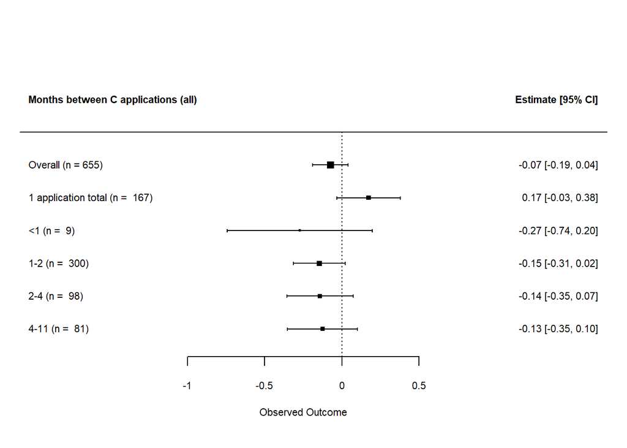

# Months applying C

## All data/fewer outliers

```r
count(nt, C_app_tm)
```

```
##    C_app_tm   n
## 1      0.00 167
## 2      1.00   6
## 3      2.00   1
## 4      3.50   1
## 5      4.00 176
## 6      5.00   1
## 7      6.00   5
## 8      7.00  11
## 9      9.00  39
## 10    10.00   2
## 11    12.00   5
## 12    13.00   3
## 13    14.00   1
## 14    15.00   4
```

[output cut: 16 more lines]

```r
nt$capt <- c()
for(i in 1:nrow(nt)) {
  if(nt$C_app_tm[i] == 0) {
    nt$capt[i] <- "1 application total"
  } else if(between(nt$C_app_tm[i], 0.001, 6)) {
    nt$capt[i] <- "1-6"
  } else if(between(nt$C_app_tm[i], 7, 12)) {
    nt$capt[i] <- "7-12"
  } else if(between(nt$C_app_tm[i], 13, 24)) {
    nt$capt[i] <- "13-24"
  } else if(between(nt$C_app_tm[i], 25, 36)) {
    nt$capt[i] <- "25-36"
  } else if(between(nt$C_app_tm[i], 37, 48)) {
    nt$capt[i] <- "37-48"
  } else {
    nt$capt[i] <- ">48"
  }
}
nt$capt <- factor(nt$capt, levels = c("1 application total", "1-6", "7-12", "13-24",
                                      "25-36", "37-48", ">48"))
```

```r
count(nt, capt)
```

```
##                  capt   n
## 1 1 application total 167
## 2                 1-6 190
## 3                7-12  57
## 4               13-24  68
## 5               25-36  21
## 6               37-48 132
## 7                 >48  20
```

```r
any(is.na(nt$capt))
```

```
## [1] FALSE
```

```r
nt.mv.capt <- rma.mv(yi = yi,
                     V = vi,
                     random = ~ 1 | exp_ID / obs_ID,
                     data = nt,
                     mods = ~ factor(capt) - 1)
```

```r
h <- c("Months applying C (all)", "Estimate [95% CI]")
single.mod.cat(nt, "capt", nt.mv, nt.mv.capt, h)
```

```
##
## Multivariate Meta-Analysis Model (k = 655; method: REML)
##
## Variance Components:
##
##             estim    sqrt  nlvls  fixed         factor
## sigma^2.1  0.0962  0.3101     53     no         exp_ID
## sigma^2.2  0.0000  0.0001    655     no  exp_ID/obs_ID
##
## Test for Residual Heterogeneity:
## QE(df = 648) = 866.5161, p-val < .0001
##
## Test of Moderators (coefficients 1:7):
## QM(df = 7) = 19.8604, p-val = 0.0059
##
## Model Results:
##
##                                  estimate      se     zval    pval    ci.lb
## factor(capt)1 application total    0.2301  0.1056   2.1782  0.0294   0.0231
## factor(capt)1-6                   -0.1934  0.0982  -1.9693  0.0489  -0.3859
## factor(capt)7-12                   0.2619  0.1680   1.5593  0.1189  -0.0673
## factor(capt)13-24                 -0.2551  0.1133  -2.2521  0.0243  -0.4772
## factor(capt)25-36                 -0.5304  0.2255  -2.3523  0.0187  -0.9724
## factor(capt)37-48                 -0.0723  0.1299  -0.5569  0.5776  -0.3268
## factor(capt)>48                   -0.1842  0.2108  -0.8735  0.3824  -0.5974
##                                    ci.ub
## factor(capt)1 application total   0.4372  *
## factor(capt)1-6                  -0.0009  *
## factor(capt)7-12                  0.5912
## factor(capt)13-24                -0.0331  *
## factor(capt)25-36                -0.0885  *
## factor(capt)37-48                 0.1822
## factor(capt)>48                   0.2291
##
## ---
## Signif. codes:  0 '***' 0.001 '**' 0.01 '*' 0.05 '.' 0.1 ' ' 1
##
## [1] QM/QT = 0.0224063183990693
```

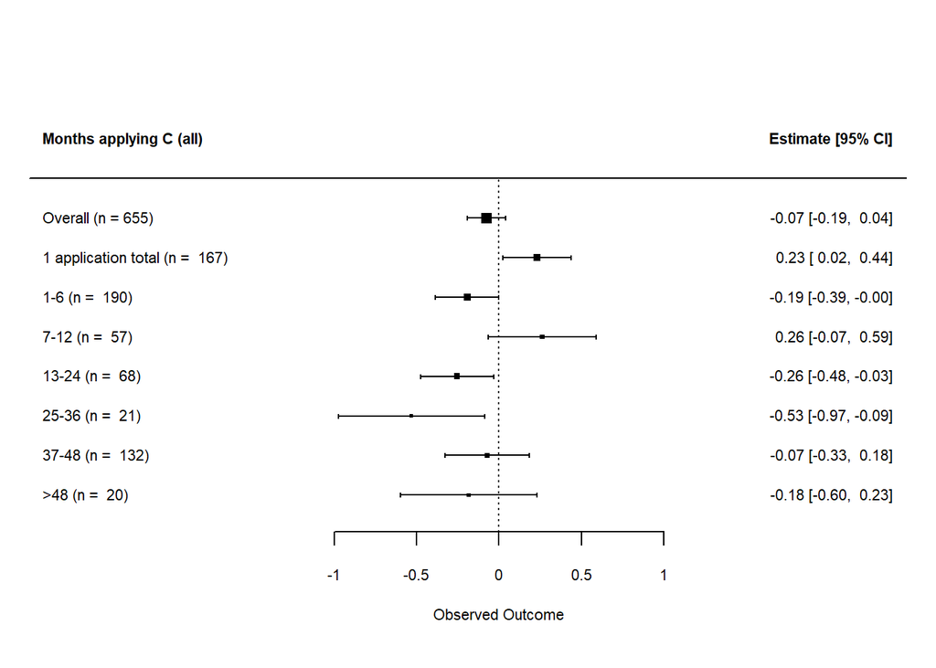

# Annual/perennial

## All data/fewer outliers

```r
any(is.na(nt$plant_anper))
```

```
## [1] FALSE
```

```r
nt.mv.panp <- rma.mv(yi = yi,
                     V = vi,
                     random = ~ 1 | exp_ID / obs_ID,
                     data = nt,
                     mods = ~ factor(plant_anper) - 1)
```

```r
h <- c("Annual/perennial (all)", "Estimate [95% CI]")
single.mod.cat(nt, "plant_anper", nt.mv, nt.mv.panp, h)
```

```
##
## Multivariate Meta-Analysis Model (k = 655; method: REML)
##
## Variance Components:
##
##             estim    sqrt  nlvls  fixed         factor
## sigma^2.1  0.1034  0.3215     53     no         exp_ID
## sigma^2.2  0.0004  0.0198    655     no  exp_ID/obs_ID
##
## Test for Residual Heterogeneity:
## QE(df = 651) = 909.1067, p-val < .0001
##
## Test of Moderators (coefficients 1:4):
## QM(df = 4) = 10.6297, p-val = 0.0311
##
## Model Results:
##
##                               estimate      se     zval    pval    ci.lb
## factor(plant_anper)annual      -0.3458  0.1155  -2.9940  0.0028  -0.5722
## factor(plant_anper)biennial    -0.2311  0.3566  -0.6481  0.5169  -0.9301
## factor(plant_anper)perennial   -0.0303  0.0608  -0.4991  0.6177  -0.1494
## factor(plant_anper)unknown     -0.1615  0.1271  -1.2701  0.2041  -0.4106
##                                 ci.ub
## factor(plant_anper)annual     -0.1194  **
## factor(plant_anper)biennial    0.4678
## factor(plant_anper)perennial   0.0888
## factor(plant_anper)unknown     0.0877
##
## ---
## Signif. codes:  0 '***' 0.001 '**' 0.01 '*' 0.05 '.' 0.1 ' ' 1
##
## [1] QM/QT = 0.0115573747349454
```

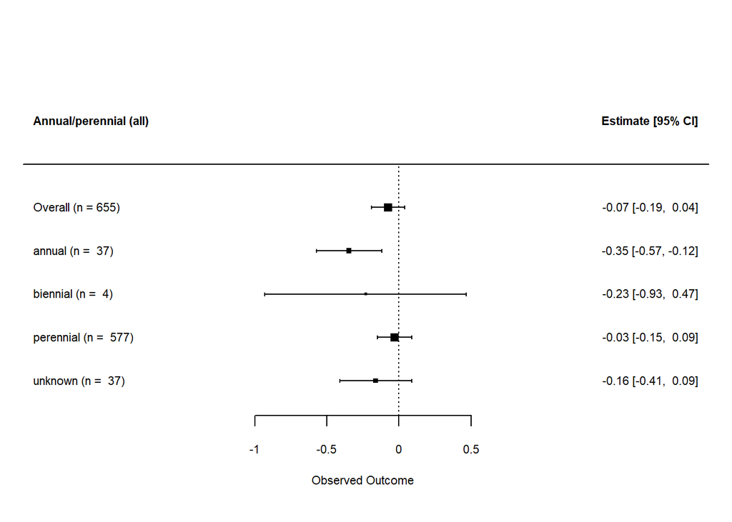

# Grass/forb/shrub

## All data/fewer outliers

```r
any(is.na(nt$plant_gfs))
```

```
## [1] FALSE
```

```r
nt.mv.pgfs <- rma.mv(yi = yi,
                     V = vi,
                     random = ~ 1 | exp_ID / obs_ID,
                     data = nt,
                     mods = ~ factor(plant_gfs) - 1)
```

```r
h <- c("Grass/forb/shrub (all)", "Estimate [95% CI]")
single.mod.cat(nt, "plant_gfs", nt.mv, nt.mv.pgfs, h)
```

```
##
## Multivariate Meta-Analysis Model (k = 655; method: REML)
##
## Variance Components:
##
##             estim    sqrt  nlvls  fixed         factor
## sigma^2.1  0.1199  0.3463     53     no         exp_ID
## sigma^2.2  0.0000  0.0001    655     no  exp_ID/obs_ID
##
## Test for Residual Heterogeneity:
## QE(df = 650) = 918.8050, p-val < .0001
##
## Test of Moderators (coefficients 1:5):
## QM(df = 5) = 4.0902, p-val = 0.5365
##
## Model Results:
##
##                             estimate      se     zval    pval    ci.lb   ci.ub
## factor(plant_gfs)forb        -0.0256  0.0777  -0.3296  0.7417  -0.1779  0.1267
## factor(plant_gfs)graminoid   -0.0683  0.0672  -1.0165  0.3094  -0.1999  0.0634
## factor(plant_gfs)shrub       -0.0248  0.1214  -0.2045  0.8380  -0.2627  0.2130
## factor(plant_gfs)subshrub    -0.2650  0.2280  -1.1627  0.2450  -0.7118  0.1817
## factor(plant_gfs)unknown     -0.1700  0.1122  -1.5152  0.1297  -0.3900  0.0499
##
## factor(plant_gfs)forb
## factor(plant_gfs)graminoid
## factor(plant_gfs)shrub
## factor(plant_gfs)subshrub
## factor(plant_gfs)unknown
##
## ---
## Signif. codes:  0 '***' 0.001 '**' 0.01 '*' 0.05 '.' 0.1 ' ' 1
##
## [1] QM/QT = 0.00443192828975222
```

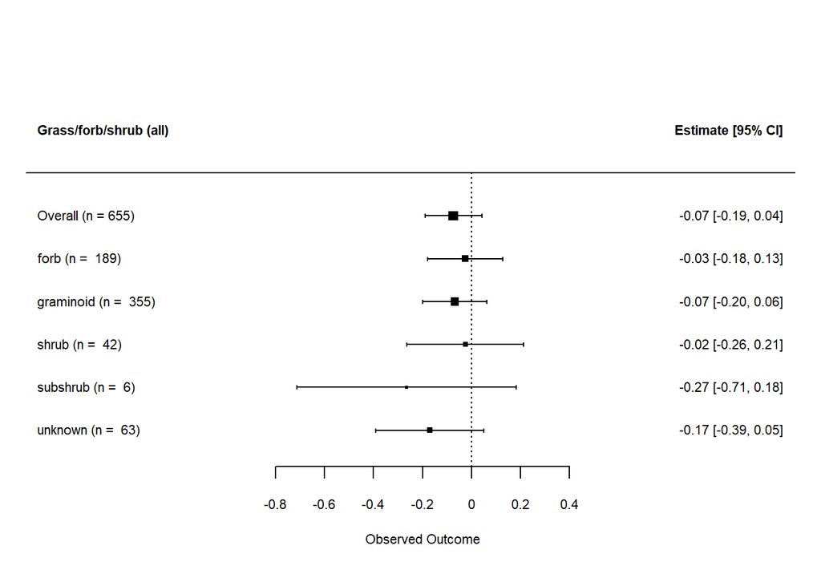

# Annual/perennial and grass/forb/shrub

## All data/fewer outliers

```r
any(is.na(nt$plant_apgfs))
```

```
## [1] FALSE
```

```r
nt.mv.papgfs <- rma.mv(yi = yi,
                     V = vi,
                     random = ~ 1 | exp_ID / obs_ID,
                     data = nt,
                     mods = ~ factor(plant_apgfs) - 1)
```

```r
h <- c("Annual/perennial and grass/forb/shrub (all)", "Estimate [95% CI]")
single.mod.cat(nt, "plant_apgfs", nt.mv, nt.mv.papgfs, h)
```

```
##
## Multivariate Meta-Analysis Model (k = 655; method: REML)
##
## Variance Components:
##
##             estim    sqrt  nlvls  fixed         factor
## sigma^2.1  0.1175  0.3428     53     no         exp_ID
## sigma^2.2  0.0000  0.0001    655     no  exp_ID/obs_ID
##
## Test for Residual Heterogeneity:
## QE(df = 642) = 881.1929, p-val < .0001
##
## Test of Moderators (coefficients 1:13):
## QM(df = 13) = 37.2272, p-val = 0.0004
##
## Model Results:
##
##                                         estimate      se     zval    pval
## factor(plant_apgfs)annual forb           -0.2320  0.1349  -1.7198  0.0855
## factor(plant_apgfs)annual graminoid      -0.5032  0.3049  -1.6507  0.0988
## factor(plant_apgfs)annual unknown        -1.0497  0.3415  -3.0735  0.0021
## factor(plant_apgfs)biennial forb         -0.1921  0.3585  -0.5359  0.5920
## factor(plant_apgfs)perennial forb         0.0913  0.0853   1.0710  0.2842
## factor(plant_apgfs)perennial graminoid   -0.0455  0.0696  -0.6534  0.5135
## factor(plant_apgfs)perennial shrub       -0.1170  0.1259  -0.9297  0.3525
## factor(plant_apgfs)perennial subshrub    -0.2922  0.2286  -1.2781  0.2012
## factor(plant_apgfs)perennial unknown     -0.0703  0.1290  -0.5447  0.5859
## factor(plant_apgfs)unknown forb          -0.4295  0.1811  -2.3718  0.0177
## factor(plant_apgfs)unknown graminoid     -0.0435  0.2038  -0.2136  0.8308
## factor(plant_apgfs)unknown shrub          1.3462  0.4482   3.0037  0.0027
## factor(plant_apgfs)unknown unknown       -0.0871  0.2680  -0.3249  0.7453
##                                           ci.lb    ci.ub
## factor(plant_apgfs)annual forb          -0.4964   0.0324   .
## factor(plant_apgfs)annual graminoid     -1.1008   0.0943   .
## factor(plant_apgfs)annual unknown       -1.7191  -0.3803  **
## factor(plant_apgfs)biennial forb        -0.8948   0.5105
## factor(plant_apgfs)perennial forb       -0.0758   0.2584
## factor(plant_apgfs)perennial graminoid  -0.1819   0.0910
## factor(plant_apgfs)perennial shrub      -0.3637   0.1297
## factor(plant_apgfs)perennial subshrub   -0.7402   0.1559
## factor(plant_apgfs)perennial unknown    -0.3231   0.1825
## factor(plant_apgfs)unknown forb         -0.7844  -0.0746   *
## factor(plant_apgfs)unknown graminoid    -0.4431   0.3560
## factor(plant_apgfs)unknown shrub         0.4678   2.2247  **
## factor(plant_apgfs)unknown unknown      -0.6122   0.4381
##
## ---
## Signif. codes:  0 '***' 0.001 '**' 0.01 '*' 0.05 '.' 0.1 ' ' 1
##
## [1] QM/QT = 0.040533941179534
```

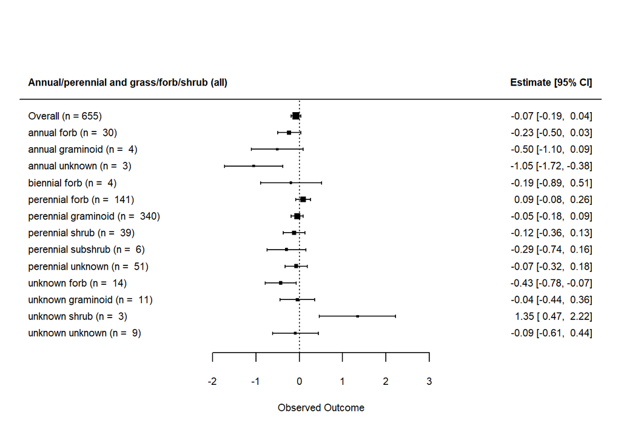

# Plot size (categorical)

## All data

```r
count(nt, plot)
```

```
##            plot   n
## 1  7.853982e-03   2
## 2  2.500000e-01  15
## 3  1.000000e+00  89
## 4  1.300000e+00   2
## 5  1.500000e+00   4
## 6  2.000000e+00   2
## 7  2.250000e+00   7
## 8  3.750000e+00 223
## 9  4.000000e+00  88
## 10 6.000000e+00  12
## 11 9.000000e+00  10
## 12 1.600000e+01  20
## 13 2.500000e+01  48
## 14 5.000000e+01   6
## 15 7.500000e+01   6
## 16 1.000000e+02 107
## 17 1.600000e+02   8
## 18           NA   6
```

```r
nt$plotc <- c()
for(i in 1:nrow(nt)) {
  if(is.na(nt$plot[i])) {
    nt$plotc[i] <- "idk"
  } else if(nt$plot[i] < 1) {
    nt$plotc[i] <- "<1"
  } else if(nt$plot[i] == 1) {
    nt$plotc[i] <- "1"
  } else if(between(nt$plot[i], 1.3, 3.75)) {
    nt$plotc[i] <- "1.3-3.75"
  } else if(nt$plot[i] == 4) {
    nt$plotc[i] <- "4"
  } else if(between(nt$plot[i], 6, 9)) {
    nt$plotc[i] <- "6-9"
  } else if(nt$plot[i] == 12) {
    nt$plotc[i] <- "12"
  } else if(between(nt$plot[i], 12.5, 16)) {
    nt$plotc[i] <- "12.5-16"
  } else if(nt$plot[i] == 25) {
    nt$plotc[i] <- "25"
  } else if(between(nt$plot[i], 28, 50)) {
    nt$plotc[i] <- "28-50"
  } else if(nt$plot[i] == 75) {
    nt$plotc[i] <- "75"
  } else {
    nt$plotc[i] <- ">100"
  }
}
nt$plotc <- factor(nt$plotc,
                           levels = c("<1", "1", "1.3-3.75", "4", "6-9", "12", "12.5-16",
                                      "25", "28-50", "75", ">100"))
```

```r
count(nt, plotc)
```

```
##       plotc   n
## 1        <1  17
## 2         1  89
## 3  1.3-3.75 238
## 4         4  88
## 5       6-9  22
## 6   12.5-16  20
## 7        25  48
## 8     28-50   6
## 9        75   6
## 10     >100 115
## 11     <NA>   6
```

```r
any(is.na(nt$plotc))
```

```
## [1] TRUE
```

```r
nt.plotc.na <- nt %>%
  filter(!is.na(plotc))

nt.mv.plotc <- rma.mv(yi = yi,
                      V = vi,
                      random = ~ 1 | exp_ID / obs_ID,
                      data = nt.plotc.na,
                      mods = ~ factor(plotc) - 1)

nt.mv.plotc.na <- rma.mv(yi = yi,
                         V = vi,
                         random = ~ 1 | exp_ID / obs_ID,
                         data = nt.plotc.na)
```

```
##
## Multivariate Meta-Analysis Model (k = 649; method: REML)
##
## Variance Components:
##
##             estim    sqrt  nlvls  fixed         factor
## sigma^2.1  0.0827  0.2875     50     no         exp_ID
## sigma^2.2  0.0000  0.0001    649     no  exp_ID/obs_ID
##
## Test for Residual Heterogeneity:
## QE(df = 639) = 824.0525, p-val < .0001
##
## Test of Moderators (coefficients 1:10):
## QM(df = 10) = 18.5659, p-val = 0.0461
##
## Model Results:
##
##                        estimate      se     zval    pval    ci.lb    ci.ub
## factor(plotc)<1          0.5137  0.2551   2.0136  0.0441   0.0137   1.0137  *
## factor(plotc)1          -0.1142  0.1239  -0.9218  0.3566  -0.3570   0.1286
## factor(plotc)1.3-3.75   -0.2338  0.0918  -2.5473  0.0109  -0.4136  -0.0539  *
## factor(plotc)4           0.0708  0.1754   0.4039  0.6863  -0.2729   0.4146
## factor(plotc)6-9        -0.0528  0.2197  -0.2402  0.8101  -0.4833   0.3778
## factor(plotc)12.5-16     0.3573  0.2602   1.3731  0.1697  -0.1527   0.8672
## factor(plotc)25          0.0476  0.2125   0.2241  0.8227  -0.3688   0.4641
## factor(plotc)28-50      -0.5495  0.3687  -1.4904  0.1361  -1.2722   0.1731
## factor(plotc)75          0.0546  0.3103   0.1758  0.8604  -0.5535   0.6626
## factor(plotc)>100       -0.2317  0.1486  -1.5588  0.1190  -0.5229   0.0596
##
## ---
## Signif. codes:  0 '***' 0.001 '**' 0.01 '*' 0.05 '.' 0.1 ' ' 1
##
## [1] QM/QT = 0.0220336291807025
```

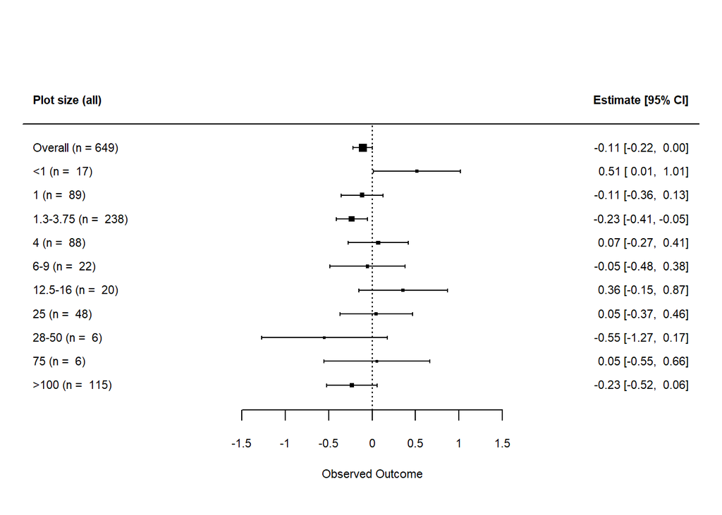

```r
h <- c("Plot size (all)", "Estimate [95% CI]")
single.mod.cat(nt.plotc.na, "plotc", nt.mv.plotc.na, nt.mv.plotc, h)
```

## Outliers removed

- There were no outliers.

# Seeding of native

## All data

```r
count(nt, seeding_native)
```

```
##    seeding_native   n
## 1             0.0 174
## 2           150.0   1
## 3           160.0   5
## 4           225.0  54
## 5           262.5   5
## 6           300.0 217
## 7           584.0   2
## 8          1300.0   6
## 9          3230.0   4
## 10         4000.0   4
## 11         8000.0   4
## 12        10000.0  15
## 13             NA 164
```

```r
nt <- nt %>%
  mutate(seedn = rep(NA, nrow(nt)))
for(i in 1:nrow(nt)) {
  if(is.na(nt$seeding_native[i])) {
    nt$seedn[i] <- "native seeded"
  } else if(nt$seeding_native[i] == 0) {
    nt$seedn[i] <- "native not seeded"
  } else {
    nt$seedn[i] <- "native seeded"
  }
}
```

```r
any(is.na(nt$seedn))
```

```
## [1] FALSE
```

```r
nt.mv.seedn <- rma.mv(yi = yi,
                      V = vi,
                      random = ~ 1 | exp_ID / obs_ID,
                      data = nt,
                      mods = ~ factor(seedn) - 1)
```

```r
h <- c("Seeding of native (all)", "Estimate [95% CI]")
single.mod.cat(nt, "seedn", nt.mv, nt.mv.seedn, h)
```

```
##
## Multivariate Meta-Analysis Model (k = 655; method: REML)
##
## Variance Components:
##
##             estim    sqrt  nlvls  fixed         factor
## sigma^2.1  0.0972  0.3118     53     no         exp_ID
## sigma^2.2  0.0000  0.0001    655     no  exp_ID/obs_ID
##
## Test for Residual Heterogeneity:
## QE(df = 653) = 894.7390, p-val < .0001
##
## Test of Moderators (coefficients 1:2):
## QM(df = 2) = 10.2446, p-val = 0.0060
##
## Model Results:
##
##                                 estimate      se     zval    pval    ci.lb
## factor(seedn)native not seeded   -0.2840  0.0915  -3.1050  0.0019  -0.4632
## factor(seedn)native seeded        0.0335  0.0663   0.5059  0.6130  -0.0964
##                                   ci.ub
## factor(seedn)native not seeded  -0.1047  **
## factor(seedn)native seeded       0.1634
##
## ---
## Signif. codes:  0 '***' 0.001 '**' 0.01 '*' 0.05 '.' 0.1 ' ' 1
##
## [1] QM/QT = 0.0113202166450891
```

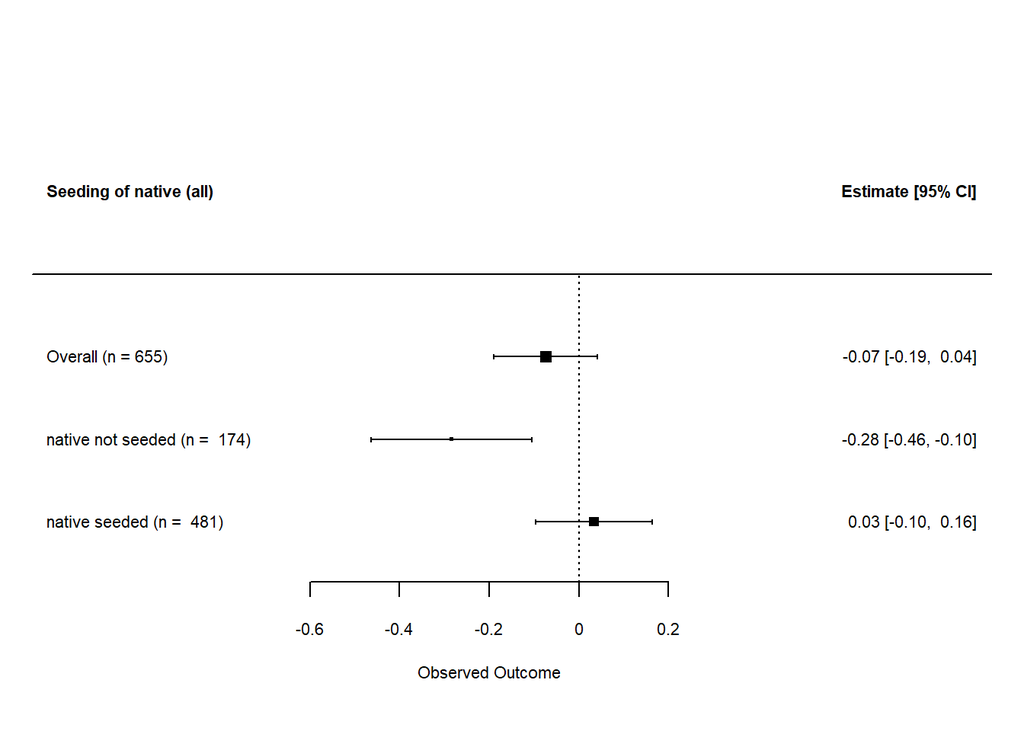

## Outliers removed

- There were no outliers.

# Discontinued moderators (no outlier analysis)

## Climate

- This moderator has too much missing data.

### All data

```r
any(is.na(nt$climate))
```

```
## [1] TRUE
```

```r
nt.clim.na <- nt %>%
  filter(!is.na(climate))

nt.mv.clim <- rma.mv(yi = yi,
                    V = vi,
                    random = ~ 1 | exp_ID / obs_ID,
                    data = nt.clim.na,
                    mods = ~ factor(climate) - 1)

nt.mv.clim.na <- rma.mv(yi = yi,
                       V = vi,
                       random = ~ 1 | exp_ID / obs_ID,
                       data = nt.clim.na)
```

```r
h <- c("Climate (all)", "Estimate [95% CI]")
single.mod.cat(nt, "climate", nt.mv.clim.na, nt.mv.clim, h)
```

```
##
## Multivariate Meta-Analysis Model (k = 69; method: REML)
##
## Variance Components:
##
##             estim    sqrt  nlvls  fixed         factor
## sigma^2.1  0.0692  0.2631     13     no         exp_ID
## sigma^2.2  0.0158  0.1258     69     no  exp_ID/obs_ID
##
## Test for Residual Heterogeneity:
## QE(df = 64) = 81.9787, p-val = 0.0644
##
## Test of Moderators (coefficients 1:5):
## QM(df = 5) = 14.1880, p-val = 0.0145
##
## Model Results:
##
##                               estimate      se     zval    pval    ci.lb
## factor(climate)continental      0.1438  0.3142   0.4577  0.6472  -0.4719
## factor(climate)Mediterranean   -0.2109  0.2143  -0.9844  0.3249  -0.6309
## factor(climate)semi-arid       -2.8158  0.8708  -3.2337  0.0012  -4.5224
## factor(climate)semiarid        -0.0966  0.1703  -0.5672  0.5706  -0.4303
## factor(climate)temperate        0.3300  0.2209   1.4937  0.1353  -0.1030
##                                 ci.ub
## factor(climate)continental     0.7595
## factor(climate)Mediterranean   0.2090
## factor(climate)semi-arid      -1.1091  **
## factor(climate)semiarid        0.2372
## factor(climate)temperate       0.7629
##
## ---
## Signif. codes:  0 '***' 0.001 '**' 0.01 '*' 0.05 '.' 0.1 ' ' 1
##
## [1] QM/QT = 0.147535214053126
```

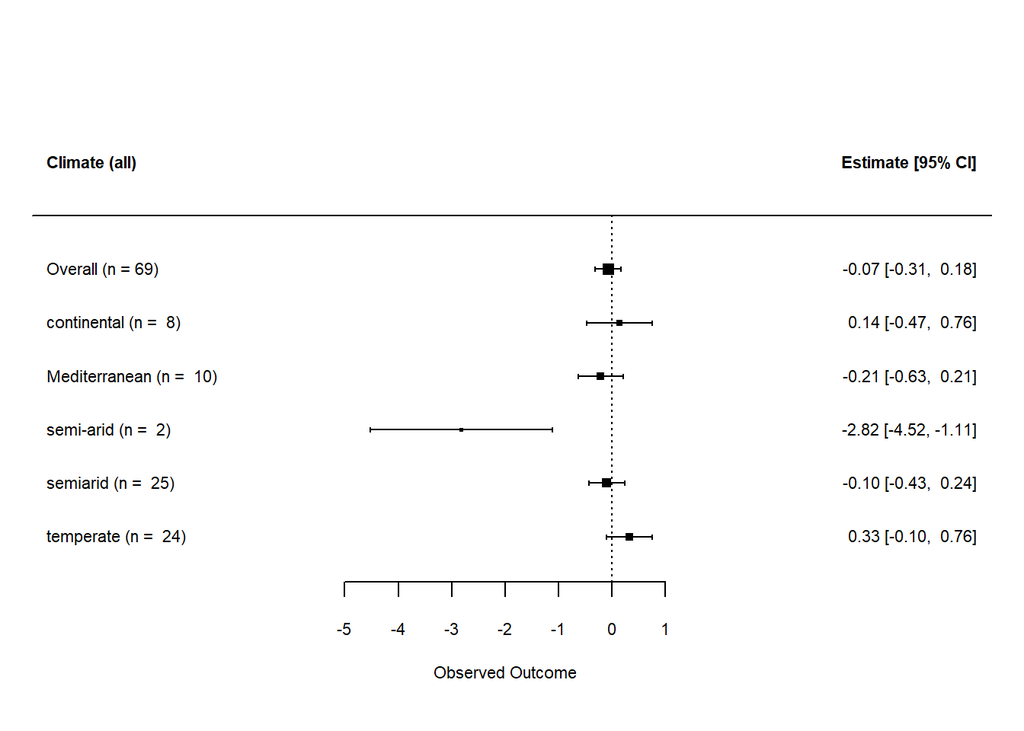

## Duration since first C app (continuous)

- The categorical version of this moderator is used instead (`dfc`).

### All data

```r
any(is.na(nt$duration_first))
```

```
## [1] FALSE
```

```r
nt.mv.df <- rma.mv(yi = yi,
                   V = vi,
                   random = ~ 1 | exp_ID / obs_ID,
                   data = nt,
                   mods = ~ duration_first)
```

```r
single.mod.cont(nt$duration_first, nt.mv.df, nt$vi, nt$yi,
                "Months since first C application", "Duration (all)")
```

```
##
## Multivariate Meta-Analysis Model (k = 655; method: REML)
##
## Variance Components:
##
##             estim    sqrt  nlvls  fixed         factor
## sigma^2.1  0.1184  0.3441     53     no         exp_ID
## sigma^2.2  0.0000  0.0001    655     no  exp_ID/obs_ID
##
## Test for Residual Heterogeneity:
## QE(df = 653) = 923.4390, p-val < .0001
##
## Test of Moderators (coefficient 2):
## QM(df = 1) = 0.1197, p-val = 0.7294
##
## Model Results:
##
##                 estimate      se     zval    pval    ci.lb   ci.ub
## intrcpt          -0.0616  0.0706  -0.8727  0.3828  -0.1999  0.0767
## duration_first   -0.0004  0.0012  -0.3459  0.7294  -0.0027  0.0019
##
## ---
## Signif. codes:  0 '***' 0.001 '**' 0.01 '*' 0.05 '.' 0.1 ' ' 1
##
## [1] QM/QT = 0.000129584385042844
```

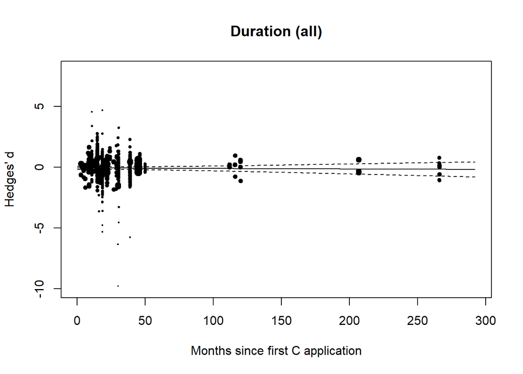

## Duration since last C application (continuous)

- The categorical version of this moderator is used instead (`dlc`).

### All data

```r
any(is.na(nt$duration_last))
```

```
## [1] FALSE
```

```r
nt.mv.dl <- rma.mv(yi = yi,
                   V = vi,
                   random = ~ 1 | exp_ID / obs_ID,
                   data = nt,
                   mods = ~ duration_last)
```

```r
single.mod.cont(nt$duration_last, nt.mv.dl, nt$vi, nt$yi,
                "Months since last C application", "Duration (all)")
```

```
##
## Multivariate Meta-Analysis Model (k = 655; method: REML)
##
## Variance Components:
##
##             estim    sqrt  nlvls  fixed         factor
## sigma^2.1  0.1194  0.3455     53     no         exp_ID
## sigma^2.2  0.0000  0.0001    655     no  exp_ID/obs_ID
##
## Test for Residual Heterogeneity:
## QE(df = 653) = 923.2566, p-val < .0001
##
## Test of Moderators (coefficient 2):
## QM(df = 1) = 2.4955, p-val = 0.1142
##
## Model Results:
##
##                estimate      se     zval    pval    ci.lb   ci.ub
## intrcpt         -0.1391  0.0724  -1.9210  0.0547  -0.2809  0.0028  .
## duration_last    0.0050  0.0031   1.5797  0.1142  -0.0012  0.0111
##
## ---
## Signif. codes:  0 '***' 0.001 '**' 0.01 '*' 0.05 '.' 0.1 ' ' 1
##
## [1] QM/QT = 0.0026956394848718
```

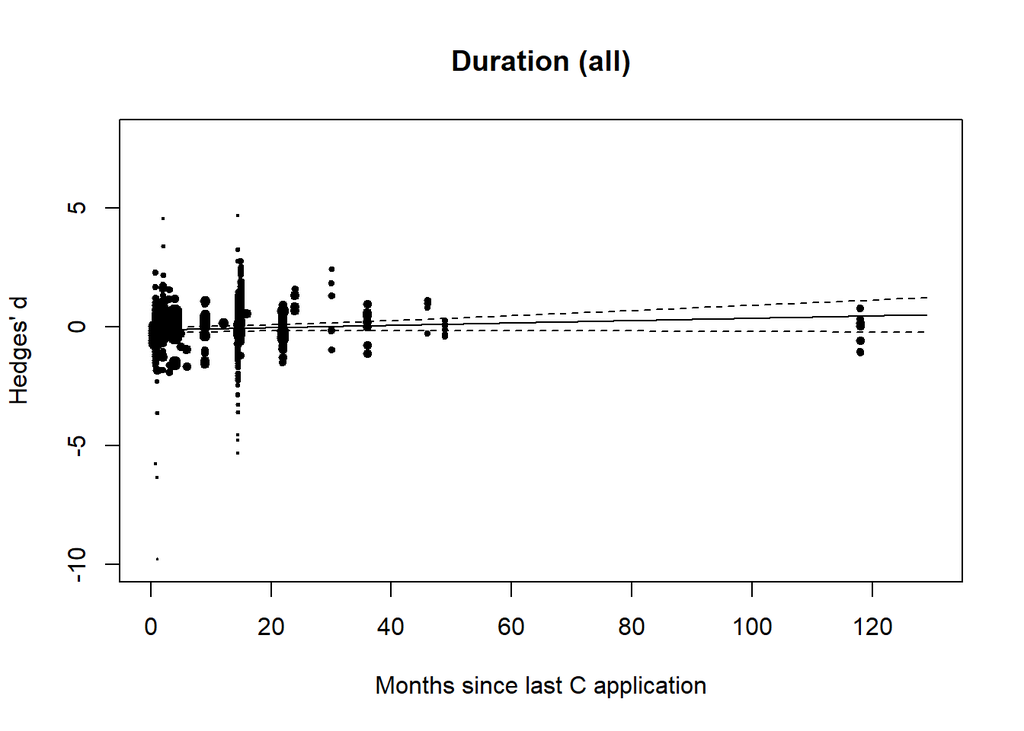

## C total

- `C_rate` is a more useful moderator, practically speaking.

### All data

```r
any(is.na(nt$C_total))
```

```
## [1] TRUE
```

```r
nt.ctot.na <- nt %>%
  filter(!is.na(C_total))

nt.mv.ctot <- rma.mv(yi = yi,
                     V = vi,
                     random = ~ 1 | exp_ID / obs_ID,
                     data = nt.ctot.na,
                     mods = ~ C_total)
```

```r
single.mod.cont(nt.ctot.na$C_total, nt.mv.ctot, nt.ctot.na$vi, nt.ctot.na$yi,
                "C total (g C/m2)", "C total (all)")
```

```
##
## Multivariate Meta-Analysis Model (k = 640; method: REML)
##
## Variance Components:
##
##             estim    sqrt  nlvls  fixed         factor
## sigma^2.1  0.1014  0.3185     49     no         exp_ID
## sigma^2.2  0.0000  0.0001    640     no  exp_ID/obs_ID
##
## Test for Residual Heterogeneity:
## QE(df = 638) = 883.3971, p-val < .0001
##
## Test of Moderators (coefficient 2):
## QM(df = 1) = 3.8325, p-val = 0.0503
##
## Model Results:
##
##          estimate      se     zval    pval    ci.lb    ci.ub
## intrcpt   -0.2002  0.0725  -2.7608  0.0058  -0.3423  -0.0581  **
## C_total    0.0001  0.0000   1.9577  0.0503  -0.0000   0.0001   .
##
## ---
## Signif. codes:  0 '***' 0.001 '**' 0.01 '*' 0.05 '.' 0.1 ' ' 1
##
## [1] QM/QT = 0.00431963881693071
```

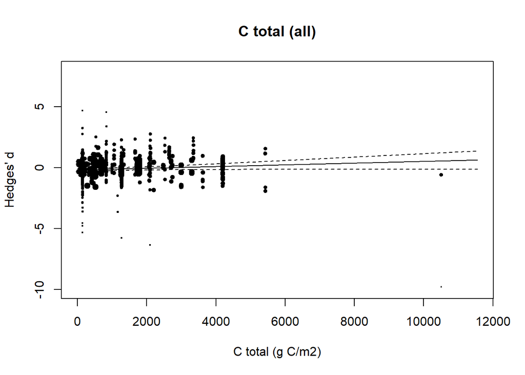

## C applications total (continuous)

- The categorical version of this moderator is used instead (`capc`).

### All data

```r
any(is.na(nt$C_app))
```

```
## [1] FALSE
```

```r
nt.mv.cap <- rma.mv(yi = yi,
                   V = vi,
                   random = ~ 1 | exp_ID / obs_ID,
                   data = nt,
                   mods = ~ C_app)
```

```r
single.mod.cont(nt$C_app, nt.mv.cap, nt$vi, nt$yi,
                "Total C applications", "C app (all)")
```

```
##
## Multivariate Meta-Analysis Model (k = 655; method: REML)
##
## Variance Components:
##
##             estim    sqrt  nlvls  fixed         factor
## sigma^2.1  0.1143  0.3381     53     no         exp_ID
## sigma^2.2  0.0000  0.0001    655     no  exp_ID/obs_ID
##
## Test for Residual Heterogeneity:
## QE(df = 653) = 913.1063, p-val < .0001
##
## Test of Moderators (coefficient 2):
## QM(df = 1) = 0.9574, p-val = 0.3279
##
## Model Results:
##
##          estimate      se     zval    pval    ci.lb   ci.ub
## intrcpt   -0.0450  0.0660  -0.6824  0.4950  -0.1744  0.0843
## C_app     -0.0030  0.0031  -0.9784  0.3279  -0.0090  0.0030
##
## ---
## Signif. codes:  0 '***' 0.001 '**' 0.01 '*' 0.05 '.' 0.1 ' ' 1
##
## [1] QM/QT = 0.00104736246326898
```

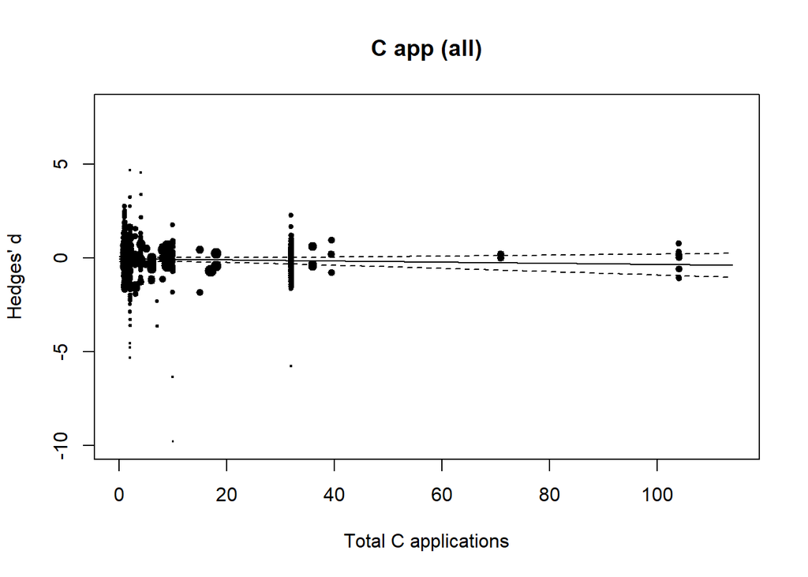

## Plant category

- `plant_apgfs` is less specific and therefore has more useful moderator levels.

### All data

```r
any(is.na(nt$plant_category))
```

```
## [1] FALSE
```

```r
nt.mv.pcat <- rma.mv(yi = yi,
                     V = vi,
                     random = ~ 1 | exp_ID / obs_ID,
                     data = nt,
                     mods = ~ factor(plant_category) - 1)
```

```r
h <- c("Plant lifeform (all)", "Estimate [95% CI]")
single.mod.cat(nt, "plant_category", nt.mv, nt.mv.pcat, h)
```

```
##
## Multivariate Meta-Analysis Model (k = 655; method: REML)
##
## Variance Components:
##
##             estim    sqrt  nlvls  fixed         factor
## sigma^2.1  0.1164  0.3411     53     no         exp_ID
## sigma^2.2  0.0000  0.0001    655     no  exp_ID/obs_ID
##
## Test for Residual Heterogeneity:
## QE(df = 631) = 857.7952, p-val < .0001
##
## Test of Moderators (coefficients 1:24):
## QM(df = 24) = 55.9936, p-val = 0.0002
##
## Model Results:
##
##                                                                estimate      se
## factor(plant_category)native                                    -0.0863  0.2673
## factor(plant_category)native annual                             -1.5178  0.4730
## factor(plant_category)native annual biennial                    -0.5338  0.4919
## factor(plant_category)native annual biennial forb               -0.8133  0.3525
## factor(plant_category)native annual biennial forb subshrub       1.0018  0.7431
## factor(plant_category)native annual forb                        -0.1570  0.1453
## factor(plant_category)native annual graminoid                   -0.5268  0.3052
## factor(plant_category)native annual perennial forb              -0.0074  0.3738
## factor(plant_category)native annual perennial graminoid          0.4996  0.2758
## factor(plant_category)native biennial forb                      -0.1811  0.3590
## factor(plant_category)native biennial perennial forb subshrub    0.1657  0.1984
## factor(plant_category)native forb                               -0.6022  0.2067
## factor(plant_category)native graminoid                          -0.2991  0.2414
## factor(plant_category)native perennial                          -0.0299  0.1311
## factor(plant_category)native perennial forb                      0.0910  0.0961
## factor(plant_category)native perennial forb shrub subshrub      -0.8129  0.5405
## factor(plant_category)native perennial forb subshrub             0.1176  0.1555
## factor(plant_category)native perennial forb vine                 0.3295  0.4875
## factor(plant_category)native perennial graminoid                -0.0379  0.0700
## factor(plant_category)native perennial shrub                     0.2240  0.2965
## factor(plant_category)native perennial shrub subshrub           -0.1783  0.1771
## factor(plant_category)native perennial shrub tree                0.1064  0.2106
```

[output cut: 67 more lines]

```
## factor(plant_category)native perennial forb
## factor(plant_category)native perennial forb shrub subshrub
## factor(plant_category)native perennial forb subshrub
## factor(plant_category)native perennial forb vine
## factor(plant_category)native perennial graminoid
## factor(plant_category)native perennial shrub
## factor(plant_category)native perennial shrub subshrub
## factor(plant_category)native perennial shrub tree
## factor(plant_category)native perennial subshrub
## factor(plant_category)native shrub                             **
##
## ---
## Signif. codes:  0 '***' 0.001 '**' 0.01 '*' 0.05 '.' 0.1 ' ' 1
##
## [1] QM/QT = 0.0612762921007482
```

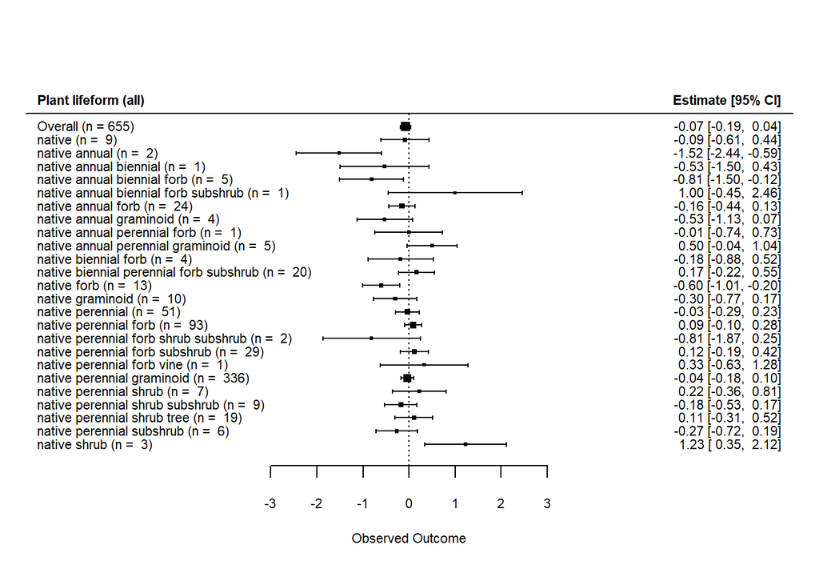

## Plant measurement

### All data

```r
any(is.na(nt$plant_measurement))
```

```
## [1] FALSE
```

```r
nt.mv.pmes <- rma.mv(yi = yi,
                     V = vi,
                     random = ~ 1 | exp_ID / obs_ID,
                     data = nt,
                     mods = ~ factor(plant_measurement) - 1)
```

```r
h <- c("Plant measurement (all)", "Estimate [95% CI]")
single.mod.cat(nt, "plant_measurement", nt.mv, nt.mv.pmes, h)
```

```
##
## Multivariate Meta-Analysis Model (k = 655; method: REML)
##
## Variance Components:
##
##             estim    sqrt  nlvls  fixed         factor
## sigma^2.1  0.0946  0.3076     53     no         exp_ID
## sigma^2.2  0.0000  0.0001    655     no  exp_ID/obs_ID
##
## Test for Residual Heterogeneity:
## QE(df = 649) = 896.7985, p-val < .0001
##
## Test of Moderators (coefficients 1:6):
## QM(df = 6) = 13.7744, p-val = 0.0323
##
## Model Results:
##
##                                                  estimate      se     zval
## factor(plant_measurement)by duration              -0.0641  0.1237  -0.5185
## factor(plant_measurement)by lifeform              -0.3104  0.1669  -1.8601
## factor(plant_measurement)by lifeform & duration   -0.9491  0.3388  -2.8011
## factor(plant_measurement)one species               0.0037  0.0624   0.0592
## factor(plant_measurement)total                    -0.0707  0.2549  -0.2774
## factor(plant_measurement)two species              -0.5495  0.3846  -1.4289
##                                                    pval    ci.lb    ci.ub
## factor(plant_measurement)by duration             0.6041  -0.3066   0.1783
## factor(plant_measurement)by lifeform             0.0629  -0.6374   0.0167   .
## factor(plant_measurement)by lifeform & duration  0.0051  -1.6132  -0.2850  **
## factor(plant_measurement)one species             0.9528  -0.1186   0.1260
## factor(plant_measurement)total                   0.7815  -0.5702   0.4288
## factor(plant_measurement)two species             0.1530  -1.3033   0.2042
##
## ---
## Signif. codes:  0 '***' 0.001 '**' 0.01 '*' 0.05 '.' 0.1 ' ' 1
##
## [1] QM/QT = 0.0151271499875792
```

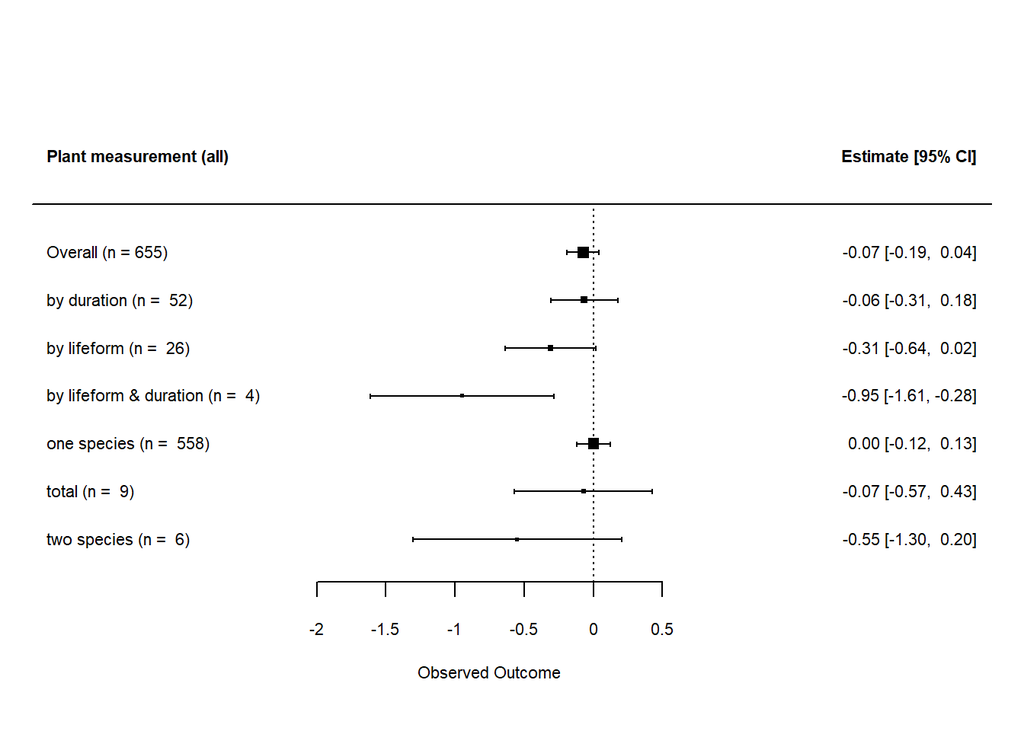

## Presence of exotic and native

- Reflects direct competition between exotic and native; however, not many studies planted native on their own.

### All data

```r
any(is.na(nt$presence))
```

```
## [1] FALSE
```

```r
nt.mv.pres <- rma.mv(yi = yi,
                     V = vi,
                     random = ~ 1 | exp_ID / obs_ID,
                     data = nt,
                     mods = ~ factor(presence) - 1)
```

```r
h <- c("Presence of exotic (all)", "Estimate [95% CI]")
single.mod.cat(nt, "presence", nt.mv, nt.mv.pres, h)
```

```
##
## Multivariate Meta-Analysis Model (k = 655; method: REML)
##
## Variance Components:
##
##             estim    sqrt  nlvls  fixed         factor
## sigma^2.1  0.1151  0.3392     53     no         exp_ID
## sigma^2.2  0.0000  0.0001    655     no  exp_ID/obs_ID
##
## Test for Residual Heterogeneity:
## QE(df = 653) = 925.5721, p-val < .0001
##
## Test of Moderators (coefficients 1:2):
## QM(df = 2) = 3.2285, p-val = 0.1990
##
## Model Results:
##
##                                  estimate      se     zval    pval    ci.lb
## factor(presence)exotic & native   -0.0948  0.0612  -1.5482  0.1216  -0.2148
## factor(presence)native only        0.0376  0.1051   0.3575  0.7207  -0.1684
##                                   ci.ub
## factor(presence)exotic & native  0.0252
## factor(presence)native only      0.2435
##
## ---
## Signif. codes:  0 '***' 0.001 '**' 0.01 '*' 0.05 '.' 0.1 ' ' 1
##
## [1] QM/QT = 0.00347601739872219
```

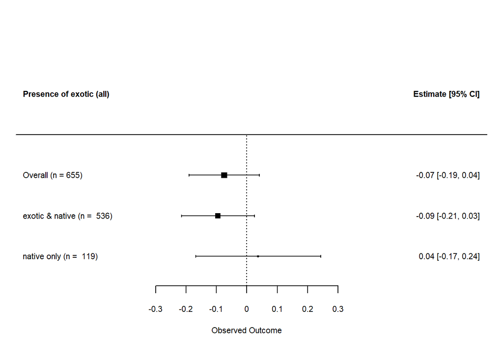

## Prior vegetation

### All data

```r
any(is.na(nt$prior_veg))
```

```
## [1] FALSE
```

```r
nt.mv.prveg <- rma.mv(yi = yi,
                      V = vi,
                      random = ~ 1 | exp_ID / obs_ID,
                      data = nt,
                      mods = ~ factor(prior_veg) - 1)
```

```r
h <- c("Prior vegetation (all)", "Estimate [95% CI]")
single.mod.cat(nt, "prior_veg", nt.mv, nt.mv.prveg, h)
```

```
##
## Multivariate Meta-Analysis Model (k = 655; method: REML)
##
## Variance Components:
##
##             estim    sqrt  nlvls  fixed         factor
## sigma^2.1  0.0455  0.2134     53     no         exp_ID
## sigma^2.2  0.0008  0.0277    655     no  exp_ID/obs_ID
##
## Test for Residual Heterogeneity:
## QE(df = 642) = 808.1963, p-val < .0001
##
## Test of Moderators (coefficients 1:13):
## QM(df = 13) = 46.4488, p-val < .0001
##
## Model Results:
##
##                                                  estimate      se     zval
## factor(prior_veg)herbicide                        -0.0749  0.0831  -0.9014
## factor(prior_veg)herbicide, mow                    0.1339  0.2321   0.5770
## factor(prior_veg)herbicide, TSR and replacement    0.9603  0.2739   3.5066
## factor(prior_veg)method unknown                    0.6204  0.2293   2.7053
## factor(prior_veg)mow                              -0.6907  0.3681  -1.8762
## factor(prior_veg)soil fumigant                     0.0571  0.2280   0.2506
## factor(prior_veg)till                              0.5032  0.2335   2.1554
## factor(prior_veg)TSR 30 cm                        -0.5497  0.3146  -1.7475
## factor(prior_veg)TSR 5 cm                         -0.2064  0.3235  -0.6380
## factor(prior_veg)TSR and replacement               0.6924  0.4134   1.6748
## factor(prior_veg)veg continued                    -0.1711  0.0675  -2.5363
## factor(prior_veg)woody removed                    -0.1380  0.2149  -0.6420
## factor(prior_veg)woody removed, herbicide, mow    -0.7091  0.3411  -2.0788
##                                                    pval    ci.lb    ci.ub
## factor(prior_veg)herbicide                       0.3674  -0.2376   0.0879
## factor(prior_veg)herbicide, mow                  0.5639  -0.3210   0.5889
## factor(prior_veg)herbicide, TSR and replacement  0.0005   0.4236   1.4971  ***
## factor(prior_veg)method unknown                  0.0068   0.1709   1.0699   **
## factor(prior_veg)mow                             0.0606  -1.4123   0.0308    .
## factor(prior_veg)soil fumigant                   0.8021  -0.3897   0.5040
## factor(prior_veg)till                            0.0311   0.0456   0.9608    *
## factor(prior_veg)TSR 30 cm                       0.0805  -1.1662   0.0668    .
## factor(prior_veg)TSR 5 cm                        0.5235  -0.8405   0.4277
## factor(prior_veg)TSR and replacement             0.0940  -0.1179   1.5028    .
## factor(prior_veg)veg continued                   0.0112  -0.3034  -0.0389    *
## factor(prior_veg)woody removed                   0.5209  -0.5593   0.2833
## factor(prior_veg)woody removed, herbicide, mow   0.0376  -1.3777  -0.0405    *
##
## ---
## Signif. codes:  0 '***' 0.001 '**' 0.01 '*' 0.05 '.' 0.1 ' ' 1
##
## [1] QM/QT = 0.0543486019433816
```

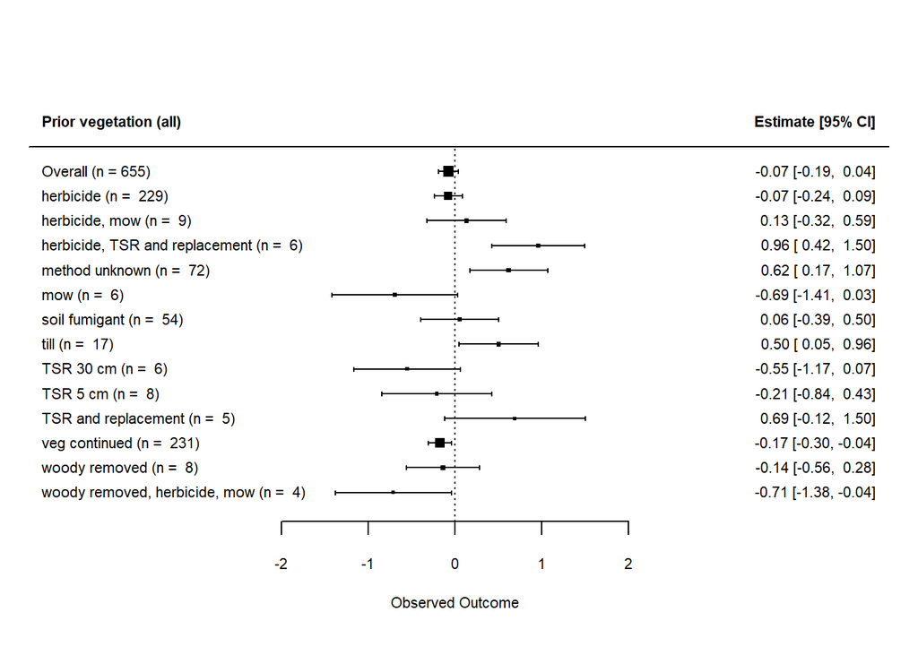

## Extent of prior veg removal

### All data

```r
any(is.na(nt$removal_extent))
```

```
## [1] FALSE
```

```r
nt.mv.pvrm <- rma.mv(yi = yi,
                     V = vi,
                     random = ~ 1 | exp_ID / obs_ID,
                     data = nt,
                     mods = ~ factor(removal_extent) - 1)
```

```r
h <- c("Extent of prior veg removal (all)", "Estimate [95% CI]")
single.mod.cat(nt, "removal_extent", nt.mv, nt.mv.pvrm, h)
```

```
##
## Multivariate Meta-Analysis Model (k = 655; method: REML)
##
## Variance Components:
##
##             estim    sqrt  nlvls  fixed         factor
## sigma^2.1  0.0952  0.3086     53     no         exp_ID
## sigma^2.2  0.0000  0.0001    655     no  exp_ID/obs_ID
##
## Test for Residual Heterogeneity:
## QE(df = 652) = 877.9852, p-val < .0001
##
## Test of Moderators (coefficients 1:3):
## QM(df = 3) = 13.3139, p-val = 0.0040
##
## Model Results:
##
##                                estimate      se     zval    pval    ci.lb
## factor(removal_extent)none      -0.1937  0.0797  -2.4300  0.0151  -0.3499
## factor(removal_extent)partial   -0.1277  0.0999  -1.2779  0.2013  -0.3235
## factor(removal_extent)total      0.2901  0.1204   2.4085  0.0160   0.0540
##                                  ci.ub
## factor(removal_extent)none     -0.0375  *
## factor(removal_extent)partial   0.0681
## factor(removal_extent)total     0.5262  *
##
## ---
## Signif. codes:  0 '***' 0.001 '**' 0.01 '*' 0.05 '.' 0.1 ' ' 1
##
## [1] QM/QT = 0.0149376536254506
```

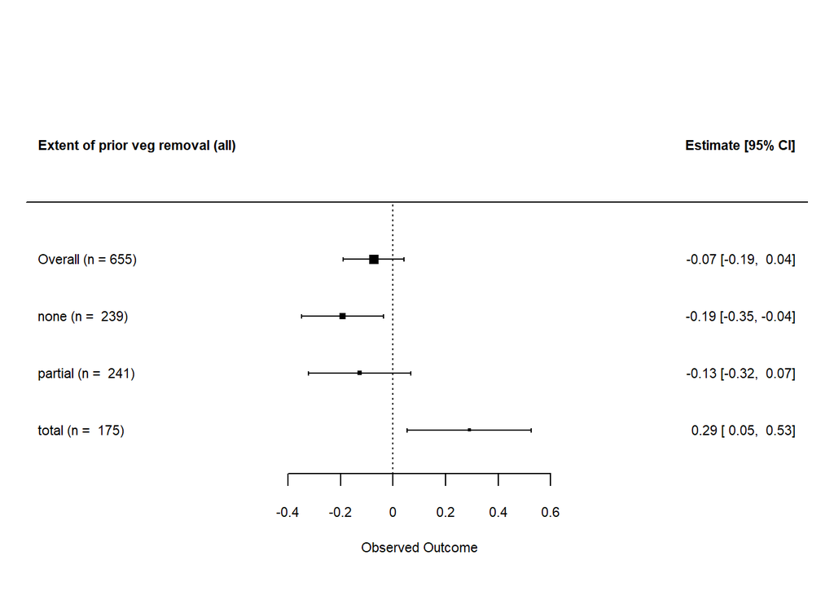

## Seeding of exotic

### All data

```r
# Turn column to presence/absence
exotic.seeded <- nt %>%
  filter(seeding_exotic != 0)
exotic.seeded$seeding_exotic_cat <- rep("exotic seeded", dim(exotic.seeded)[1])
exotic.unseed.obs <- setdiff(nt$obs_ID, exotic.seeded$obs_ID)
exotic.unseed <- nt %>%
  filter(obs_ID %in% exotic.unseed.obs)
exotic.unseed$seeding_exotic_cat <- rep("exotic not seeded", dim(exotic.unseed)[1])
nt.seede <- rbind(exotic.seeded, exotic.unseed)
```

```r
any(is.na(nt.seede$seeding_exotic_cat))
```

```
## [1] FALSE
```

```r
nt.mv.seede <- rma.mv(yi = yi,
                      V = vi,
                      random = ~ 1 | exp_ID / obs_ID,
                      data = nt.seede,
                      mods = ~ factor(seeding_exotic_cat) - 1)
```

```r
h <- c("Seeding of exotic (all)", "Estimate [95% CI]")
single.mod.cat(nt.seede, "seeding_exotic_cat", nt.mv, nt.mv.seede, h)
```

```
##
## Multivariate Meta-Analysis Model (k = 655; method: REML)
##
## Variance Components:
##
##             estim    sqrt  nlvls  fixed         factor
## sigma^2.1  0.1160  0.3406     53     no         exp_ID
## sigma^2.2  0.0000  0.0001    655     no  exp_ID/obs_ID
##
## Test for Residual Heterogeneity:
## QE(df = 653) = 923.6299, p-val < .0001
##
## Test of Moderators (coefficients 1:2):
## QM(df = 2) = 1.6711, p-val = 0.4336
##
## Model Results:
##
##                                              estimate      se     zval    pval
## factor(seeding_exotic_cat)exotic not seeded   -0.0704  0.0605  -1.1634  0.2447
## factor(seeding_exotic_cat)exotic seeded       -0.0975  0.0944  -1.0328  0.3017
##                                                ci.lb   ci.ub
## factor(seeding_exotic_cat)exotic not seeded  -0.1890  0.0482
## factor(seeding_exotic_cat)exotic seeded      -0.2826  0.0875
##
## ---
## Signif. codes:  0 '***' 0.001 '**' 0.01 '*' 0.05 '.' 0.1 ' ' 1
##
## [1] QM/QT = 0.00180602956229585
```

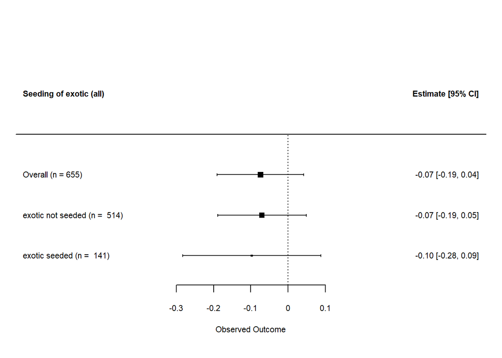